# PRS Ethnicity

2024-03-09

## PRS ethnicity

```r
library(lubridate)  # Date library from the tidyverse.
library(tidyverse)  # Data wrangling packages.
library(bigrquery)  # Data extraction from Google BigQuery
library(data.table)
library(dplyr)
require(broom)
require(tidyr)
require(ggplot2)
require(data.table)
require(ggridges)
library(survival)
```

## We note that the portion of individuals by PC predicted ancestry is as follows:

```r
table(ethnicity$ancestry_pred_other)
```

```
##
##    afr    amr    eas    eur    mid    oth    sas
##  53944  40838   5381 123072    528  19289   2342
```

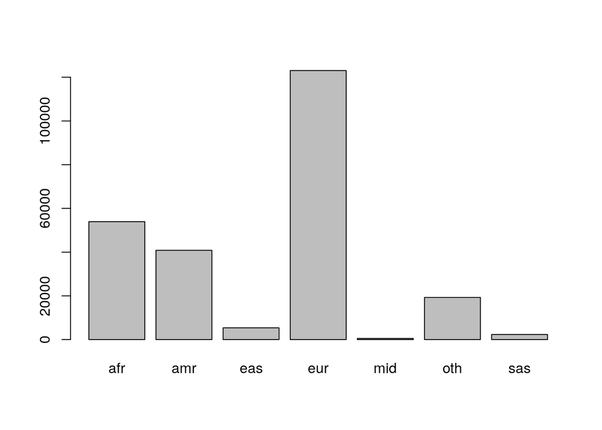

```r
barplot(table(t(ethnicity$ancestry_pred_other)))
```

Now we’ll susbet each set of LDL by the appropriate predicted ancestry results. Recall that some individuals may not have PRS scorable based on genotyping data availability.

```r
ldl_prs_afr=ldl_prs[ldl_prs$ancestry_pred_other=="afr",c(2,4)]
ldl_prs_eur=ldl_prs[ldl_prs$ancestry_pred_other=="eur",c(2,7)]
ldl_prs_amr=ldl_prs[ldl_prs$ancestry_pred_other=="amr",c(2,7)]
ldl_prs_eas=ldl_prs[ldl_prs$ancestry_pred_other=="eas",c(2,5)]
ldl_prs_sas=ldl_prs[ldl_prs$ancestry_pred_other=="sas",c(2,8)]
colnames(ldl_prs_afr)=colnames(ldl_prs_eas)=colnames(ldl_prs_amr)=colnames(ldl_prs_sas)=colnames(ldl_prs_eur)=c("IID","SCORE1_SUM")
```

Similarly we can summarize the ages of cases and controls:

```r
summary(pheno_cad$total_censor_age[pheno_cad$total_pheno==1])
```

```
##     Min.  1st Qu.   Median     Mean  3rd Qu.     Max.
##  -0.3888  52.1024  61.0088  60.3558  69.5401 100.5359
```

```r
summary(pheno_cad$total_censor_age[pheno_cad$total_pheno==0])
```

```
##    Min. 1st Qu.  Median    Mean 3rd Qu.    Max.
##   17.55   36.61   52.56   51.26   65.16  121.97
```

```r
summary(as.factor(ethnicity$ancestry_pred))
```

```
##    afr    amr    eas    eur    mid    sas
##  56913  45035   5706 133581    942   3217
```

```r
prs_AFR=merge(ldl_prs_afr[,c("IID","SCORE1_SUM")],
              ethnicity[ethnicity$ancestry_pred=="afr",c("research_id","ancestry_pred")],
              by.x="IID",by.y="research_id")
print(nrow(prs_AFR))
```

```
## [1] 53944
```

```r
prs_EUR=merge(ldl_prs_eur[,c("IID","SCORE1_SUM")],
              ethnicity[ethnicity$ancestry_pred=="eur",c("research_id","ancestry_pred")],
              by.x="IID",by.y="research_id")
print(nrow(prs_EUR))
```

```
## [1] 123072
```

```r
prs_SAS=merge(ldl_prs_sas[,c("IID","SCORE1_SUM")],
              ethnicity[ethnicity$ancestry_pred=="sas",c("research_id","ancestry_pred")],
              by.x="IID",by.y="research_id")
print(nrow(prs_SAS))
```

```
## [1] 2342
```

```r
prs_EAS=merge(ldl_prs_eas[,c("IID","SCORE1_SUM")],
              ethnicity[ethnicity$ancestry_pred=="eas",c("research_id","ancestry_pred")],
              by.x="IID",by.y="research_id")
print(nrow(prs_EAS))
```

```
## [1] 5381
```

```r
prs_AMR=merge(ldl_prs_amr[,c("IID","SCORE1_SUM")],
              ethnicity[ethnicity$ancestry_pred=="amr",c("research_id","ancestry_pred")],
              by.x="IID",by.y="research_id")
print(nrow(prs_AMR))
```

```
## [1] 40838
```

## let’s look at scores before normalization

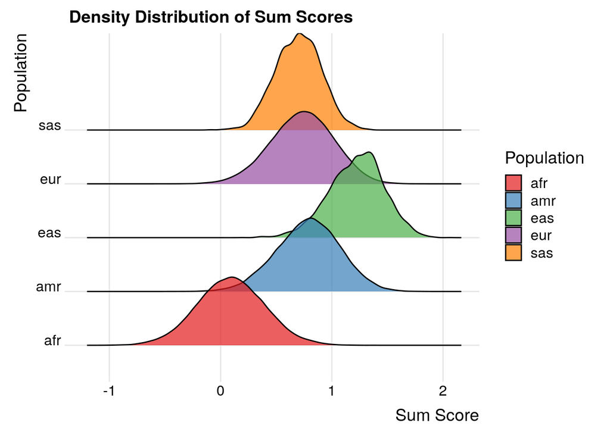

```r
combined_data <- rbind(prs_AFR, prs_EUR, prs_SAS,prs_AMR,prs_EAS)

colnames(combined_data)=c("ID","PRS","Population")
combined_data$Population=as.factor(combined_data$Population)
ggplot(combined_data, aes(x = PRS, y = Population, fill = Population)) +
   geom_density_ridges(alpha = 0.7) +
    scale_fill_brewer(palette = "Set1") +
    theme_ridges() + # Optional: Adds a nice theme suitable for ridgeline plots
     labs(title = "Density Distribution of Sum Scores",
     x = "Sum Score",
     y = "Population")
```

We notice a population imbalance, so now we merged with covariates so we can model on PC

```r
totaldata=merge(combined_data,covs,by.x="ID",by.y="person_id")

dim(totaldata)
```

```
## [1] 225577     24
```

```r
pcmod=lm(PRS~PC1+PC2+PC3+PC4+PC5,data = totaldata)
totaldata$predictscore=predict(object = pcmod,newdata=totaldata)
totaldata$residscore=(totaldata$PRS-totaldata$predictscore)
totaldata$Population=as.factor(totaldata$Population)
```

## here are all the residualised scores

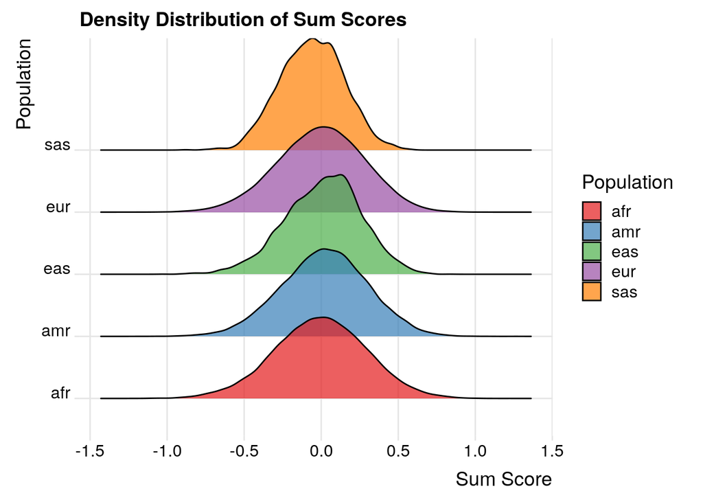

```r
ggplot(totaldata, aes(x = residscore, y = Population, fill = Population)) +
    geom_density_ridges(alpha = 0.7) +
    scale_fill_brewer(palette = "Set1") +
    theme_ridges() + # Optional: Adds a nice theme suitable for ridgeline plots
    labs(title = "Density Distribution of Sum Scores",
         x = "Sum Score",
         y = "Population")
```

We can scale the scores by all populatios jointly but note that SAS is depleted and EAS slightly enriched for high risk PRS:

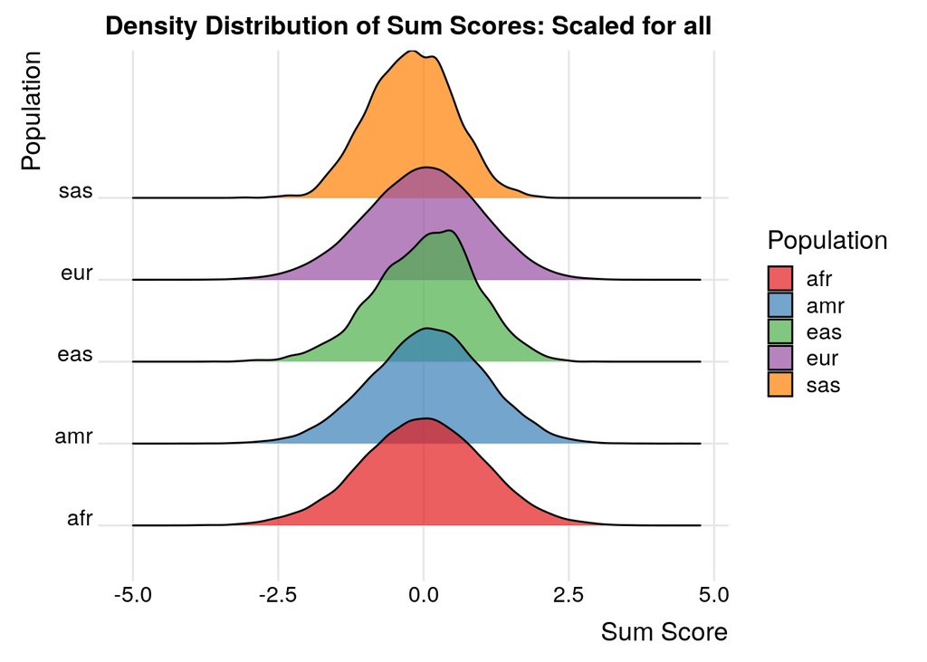

```r
totaldata$scaled_residscore=scale(totaldata$residscore)
ggplot(totaldata, aes(x = scaled_residscore, y = Population, fill = Population)) +
    geom_density_ridges(alpha = 0.7) +
    scale_fill_brewer(palette = "Set1") +
    theme_ridges() + # Optional: Adds a nice theme suitable for ridgeline plots
    labs(title = "Density Distribution of Sum Scores: Scaled for all",
         x = "Sum Score",
         y = "Population")
```

```r
totaldata%>%group_by(Population)%>%summarize(quantile(scaled_residscore,0.25),median(scaled_residscore),quantile(scaled_residscore,0.75))
```

```
## # A tibble: 5 × 4
##   Population `quantile(scaled_residscore, 0.25)` `median(scaled_residscore)`
##   <fct>                                    <dbl>                       <dbl>
## 1 afr                                     -0.717                     -0.0107
## 2 amr                                     -0.578                      0.0855
## 3 eas                                     -0.539                      0.0910
## 4 eur                                     -0.672                      0.0115
## 5 sas                                     -0.710                     -0.198
## # ℹ 1 more variable: `quantile(scaled_residscore, 0.75)` <dbl>
```

```r
totaldata$pop_scaled_prs=rep(0,nrow(totaldata))
totaldata$pop_scaled_prs[totaldata$Population%in%"afr"]=scale(totaldata$residscore[totaldata$Population%in%"afr"])
totaldata$pop_scaled_prs[totaldata$Population%in%"eur"]=scale(totaldata$residscore[totaldata$Population%in%"eur"])
totaldata$pop_scaled_prs[totaldata$Population%in%"sas"]=scale(totaldata$residscore[totaldata$Population%in%"sas"])
totaldata$pop_scaled_prs[totaldata$Population%in%"eas"]=scale(totaldata$residscore[totaldata$Population%in%"eas"])
totaldata$pop_scaled_prs[totaldata$Population%in%"amr"]=scale(totaldata$residscore[totaldata$Population%in%"amr"])

summary(totaldata$pop_scaled_prs)
```

```
##     Min.  1st Qu.   Median     Mean  3rd Qu.     Max.
## -4.66995 -0.66437  0.01922  0.00000  0.68264  4.43926
```

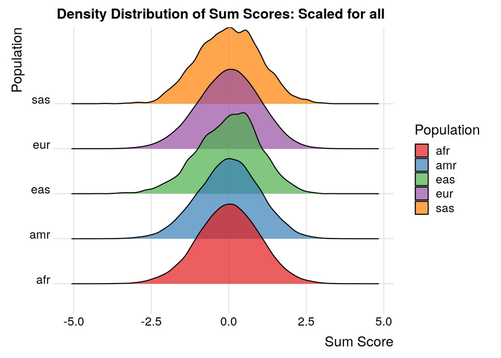

```r
ggplot(totaldata, aes(x = pop_scaled_prs, y = Population, fill = Population)) +
    geom_density_ridges(alpha = 0.7) +
    scale_fill_brewer(palette = "Set1") +
    theme_ridges() + # Optional: Adds a nice theme suitable for ridgeline plots
    labs(title = "Density Distribution of Sum Scores: Scaled for all",
         x = "Sum Score",
         y = "Population")
```

```r
library(dplyr)
totaldata%>%group_by(Population)%>%summarize(quantile(pop_scaled_prs,0.25),median(pop_scaled_prs),quantile(pop_scaled_prs,0.75))
```

```
## # A tibble: 5 × 4
##   Population `quantile(pop_scaled_prs, 0.25)` `median(pop_scaled_prs)`
##   <fct>                                 <dbl>                    <dbl>
## 1 afr                                  -0.664                  0.00985
## 2 amr                                  -0.661                  0.0174
## 3 eas                                  -0.665                  0.0622
## 4 eur                                  -0.665                  0.0228
## 5 sas                                  -0.698                  0.0126
## # ℹ 1 more variable: `quantile(pop_scaled_prs, 0.75)` <dbl>
```

We see that this has largely resolved the issues in quantile differences between populations:

# Merge with ldl,

note this is a smaller subset we will use to assess the coefficient for scaling puproses

```r
ldldat=merge(totaldata,pheno_ldl[,c("person_id","max_measurement")],by.x="ID",by.y="person_id")
ldldat=ldldat[!is.na(ldldat$max_measurement),]
caddat=merge(totaldata,pheno_cad,by.x="ID",by.y="person_id")
caddat=caddat[!is.na(caddat$total_pheno),]
dim(ldldat)
```

```
## [1] 92723    29
```

```r
dim(caddat)
```

```
## [1] 225571     37
```

```r
ldldat%>%group_by(Population)%>%summarise("mean_max"=mean(max_measurement),"med_max"=median(max_measurement),IQR(max_measurement),"number_measured"=length(max_measurement),"percent_female"=mean(sex_report=="Female"),"measurement_age"=mean(age))
```

```
## # A tibble: 5 × 7
##   Population mean_max med_max `IQR(max_measurement)` number_measured
##   <fct>         <dbl>   <dbl>                  <dbl>           <int>
## 1 afr            124.    121.                   55             18390
## 2 amr            124.    122                    57             12902
## 3 eas            124.    121                    54.5            1806
## 4 eur            127.    126                    53             58662
## 5 sas            124.    121                    50               963
## # ℹ 2 more variables: percent_female <dbl>, measurement_age <dbl>
```

```r
caddat%>%group_by(Population)%>%
  summarise("event_rate"=mean(total_pheno),"total_subjects"=length(total_pheno),"percent_female"=mean(sex_report=="Female"),"enrollment_age"=mean(enrollment_age))
```

```
## # A tibble: 5 × 5
##   Population event_rate total_subjects percent_female enrollment_age
##   <fct>           <dbl>          <int>          <dbl>          <dbl>
## 1 afr            0.0656          53942          0.555           49.6
## 2 amr            0.0453          40837          0.652           44.9
## 3 eas            0.0256           5381          0.626           44.4
## 4 eur            0.0750         123069          0.586           55.5
## 5 sas            0.0406           2342          0.488           42.3
```

Note that there are three choices for PRS, we can use :

- the overall (unscaled) residual,
- the scaled (overall residuals),
- the population scaled residual
- Here we use the populations scaled residuals

```r
library(tidyr)
populations <- levels(as.factor(caddat$Population))
library(survival)
#Initialize an empty list for storing models and results
cox_models <- list()
glm_models = list()


# Before the loop
results <- data.frame(
  Population = character(),
  PRS_Mean = numeric(),
  PRS_SD = numeric(),
  Percent_male = numeric(),
  LDL_Coef_CI_Lower = numeric(),
  LDL_Coef_CI_Upper = numeric(),
  Population_Scale_Factor = numeric(),
  LDL_Scaled_Coef_CI_Lower = numeric(),
  LDL_Scaled_Coef_CI_Upper = numeric(),
  HR=numeric(),
  HR_CI_Lower = numeric(),
  HR_CI_Upper = numeric(),
  OR = numeric(),
  OR_LCI = numeric(),
  OR_UCI = numeric(),
  stringsAsFactors = FALSE
)

for (pop in populations) {
  # Your existing data subsetting and model fitting code here

   pop_data_ldl <- subset(ldldat, Population == pop)
  pop_data_cad <- subset(caddat, Population == pop)
  pop_data_ldl$PRS <- pop_data_ldl$pop_scaled_prs
  pop_data_ldl$sex <- factor(ifelse(pop_data_ldl$sex_report == "Male", 1, 0))
  pop_data_cad$sex <- factor(ifelse(pop_data_cad$sex_report == "Male", 1, 0))

  # Linear Regression for LDL-C Levels
  ldl_model <- lm(max_measurement ~ PRS + as.numeric(age) + sex +  PC1 + PC2 + PC3 + PC4 + PC5 + PC6 + PC7 + PC8 + PC9 +
        PC10, data = pop_data_ldl)
  ldl_model_2_coef <- confint(ldl_model, "PRS")

  prs_scale_factor <- 40 / coef(ldl_model)["PRS"]
  pop_data_ldl$scaled_ldl_prs <- pop_data_ldl$PRS / prs_scale_factor
  pop_data_cad$scaled_ldl_prs <- pop_data_cad$PRS / prs_scale_factor

  ldl_model_2 <- lm(max_measurement ~ scaled_ldl_prs + as.numeric(age) + sex +  PC1 + PC2 + PC3 + PC4 + PC5 + PC6 + PC7 + PC8 + PC9 +
        PC10, data = pop_data_ldl)
  ldl_scaled_coef_ci <- confint(ldl_model_2, "scaled_ldl_prs")

  # Cox or GLM for CAD: for cox you DO NOT control for age since it's in tere
  cox_model <- coxph(Surv(total_censor_age, total_pheno) ~ scaled_ldl_prs + sex +  PC1 + PC2 + PC3 + PC4 + PC5 + PC6 + PC7 + PC8 + PC9 +PC10, data = pop_data_cad)

  glm_model <- glm(total_pheno ~ scaled_ldl_prs + as.numeric(age) + sex +  PC1 + PC2 + PC3 + PC4 + PC5 + PC6 + PC7 + PC8 + PC9 +
        PC10, data = pop_data_cad, family = "binomial")

    log_or = summary(glm_model)$coefficients["scaled_ldl_prs", "Estimate"]
  log_or_se = summary(glm_model)$coefficients["scaled_ldl_prs", "Std. Error"]
  or = round(exp(log_or), 2)
  lci = round(exp(log_or - 1.96 * log_or_se), 2)
  uci = round(exp(log_or + 1.96 * log_or_se), 2)

  cox_summary <- summary(cox_model)
  glm_summary <- summary(glm_model)

  cox_models[[pop]] <- cox_model
  glm_models[[pop]] = glm_model

  # Calculate PRS mean and standard deviation
  prs_mean <- mean(pop_data_ldl$PRS)
  prs_sd <- sd(pop_data_ldl$PRS)


  # Calculate Male/Female ratio or any other appropriate sex summary
  sex_male <- mean(pop_data_ldl$sex == 1)

  # Extract LDL model coefficients and CI directly
  ldl_coef_ci <- confint(ldl_model, "PRS")

  # Adjust for scale factor and re-calculate for scaled model if needed

  # Cox and GLM model summaries for HR and OR, with CIs

  # Append to results
  results <- rbind(results, data.frame(
    Population = pop,
    PRS_Mean = prs_mean,
    PRS_SD = prs_sd,
    Percent_male = sex_male,
    LDL_Coef_CI_Lower = ldl_coef_ci[1],
    LDL_Coef_CI_Upper = ldl_coef_ci[2],
    Population_Scale_Factor = prs_scale_factor,
    LDL_Scaled_Coef_CI_Lower = ldl_scaled_coef_ci[1], # Adjust according to your calculations
    LDL_Scaled_Coef_CI_Upper = ldl_scaled_coef_ci[2],
    HR = cox_summary$conf.int["scaled_ldl_prs", 1],
    HR_CI_Lower = cox_summary$conf.int["scaled_ldl_prs", 3], # Assuming 'cox_summary' is properly defined
    HR_CI_Upper = cox_summary$conf.int["scaled_ldl_prs", 4], # Assuming 'cox_summary' is properly defined
    OR = or,
    OR_LCI = lci,
    OR_UCI = uci
  ))
}

print(results)
```

```
##      Population     PRS_Mean    PRS_SD Percent_male LDL_Coef_CI_Lower
## PRS         afr  0.009270467 1.0018540    0.3251767          9.642123
## PRS1        amr  0.026068342 1.0052254    0.3040614          8.858953
## PRS2        eas  0.012882621 1.0160794    0.3394241          7.861739
## PRS3        eur  0.006538755 0.9990931    0.3957928          9.343864
## PRS4        sas -0.001870501 1.0279236    0.4807892          6.555127
##      LDL_Coef_CI_Upper Population_Scale_Factor LDL_Scaled_Coef_CI_Lower
## PRS          10.744033                3.924232                 37.83793
## PRS1         10.139583                4.210851                 37.30373
## PRS2         11.163758                4.204884                 33.05770
## PRS3          9.946435                4.147162                 38.75052
## PRS4         10.980335                4.562184                 29.90569
##      LDL_Scaled_Coef_CI_Upper       HR HR_CI_Lower HR_CI_Upper   OR OR_LCI
## PRS                  42.16207 2.634213  1.70410882    4.071967 2.59   1.64
## PRS1                 42.69627 2.821976  1.41324693    5.634932 2.90   1.40
## PRS2                 46.94230 1.817187  0.09789541   33.731583 2.25   0.11
## PRS3                 41.24948 3.606217  2.67500209    4.861604 3.69   2.67
## PRS4                 50.09431 1.305141  0.01230063  138.480099 2.44   0.02
##      OR_UCI
## PRS    4.09
## PRS1   6.01
## PRS2  46.21
## PRS3   5.09
## PRS4 347.48
```

## make a nice plot

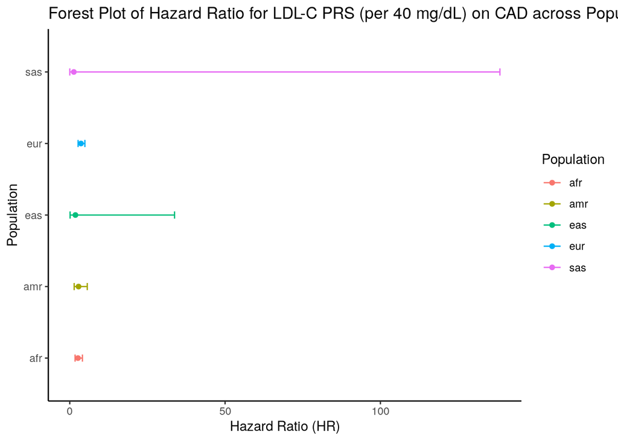

```r
library(tidyr)

ggplot(results, aes(x = Population, y = HR, ymin = HR_CI_Lower , ymax = HR_CI_Upper,col=Population)) +
    geom_point() +
    geom_errorbar(aes(ymin = HR_CI_Lower , ymax = HR_CI_Upper), width = 0.1) +
    coord_flip()+
    xlab("Population") +
    ylab("Hazard Ratio (HR)") +
    ggtitle("Forest Plot of Hazard Ratio for LDL-C PRS (per 40 mg/dL) on CAD across Populations: AOU") +theme_classic()
```

And now for OR

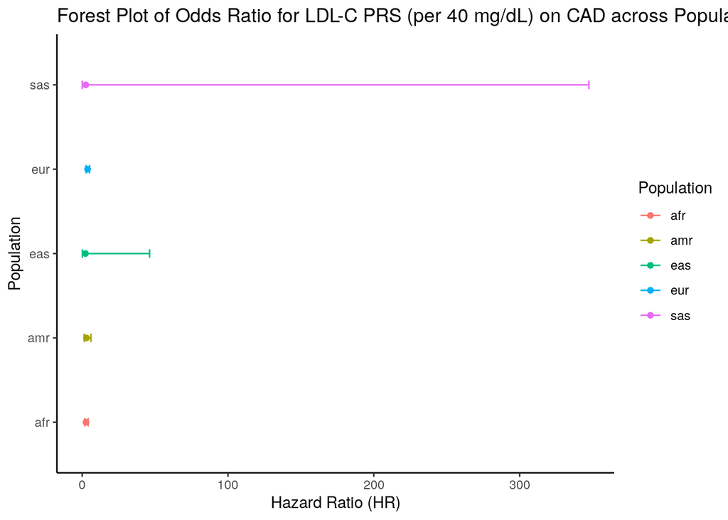

```r
ggplot(results, aes(x = Population, y = OR, ymin = OR_LCI , ymax = OR_UCI,col=Population)) +
    geom_point() +
    geom_errorbar(aes(ymin = OR_LCI, ymax = OR_UCI), width = 0.1) +
    coord_flip()+
    xlab("Population") +
    ylab("Hazard Ratio (HR)") +
    ggtitle("Forest Plot of Odds Ratio for LDL-C PRS (per 40 mg/dL) on CAD across Populations: AOU") +theme_classic()
```

## Repeat with overall scaled residuals

```r
# Before the loop
results <- data.frame(
  Population = character(),
  PRS_Mean = numeric(),
  PRS_SD = numeric(),
  Percent_male = numeric(),
  LDL_Coef_CI_Lower = numeric(),
  LDL_Coef_CI_Upper = numeric(),
  Population_Scale_Factor = numeric(),
  LDL_Scaled_Coef_CI_Lower = numeric(),
  LDL_Scaled_Coef_CI_Upper = numeric(),
  HR=numeric(),
  HR_CI_Lower = numeric(),
  HR_CI_Upper = numeric(),
  OR = numeric(),
  OR_LCI = numeric(),
  OR_UCI = numeric(),
  stringsAsFactors = FALSE
)

for (pop in populations) {
  # Your existing data subsetting and model fitting code here

   pop_data_ldl <- subset(ldldat, Population == pop)
  pop_data_cad <- subset(caddat, Population == pop)
  pop_data_ldl$PRS <- pop_data_ldl$scaled_residscore


  pop_data_ldl$sex <- factor(ifelse(pop_data_ldl$sex_report == "Male", 1, 0))
  pop_data_cad$sex <- factor(ifelse(pop_data_cad$sex_report == "Male", 1, 0))

  # Linear Regression for LDL-C Levels
  ldl_model <- lm(max_measurement ~ PRS + as.numeric(age) + sex +  PC1 + PC2 + PC3 + PC4 + PC5 + PC6 + PC7 + PC8 + PC9 +
        PC10, data = pop_data_ldl)
  ldl_model_2_coef <- confint(ldl_model, "PRS")

  prs_scale_factor <- 40 / coef(ldl_model)["PRS"]
  pop_data_ldl$scaled_ldl_prs <- pop_data_ldl$PRS / prs_scale_factor
  pop_data_cad$scaled_ldl_prs <- pop_data_cad$PRS / prs_scale_factor

  ldl_model_2 <- lm(max_measurement ~ scaled_ldl_prs + as.numeric(age) + sex +  PC1 + PC2 + PC3 + PC4 + PC5 + PC6 + PC7 + PC8 + PC9 +
        PC10, data = pop_data_ldl)
  ldl_scaled_coef_ci <- confint(ldl_model_2, "scaled_ldl_prs")

  # Cox or GLM for CAD: for cox you DO NOT control for age since it's in tere
  cox_model <- coxph(Surv(total_censor_age, total_pheno) ~ scaled_ldl_prs + sex +  PC1 + PC2 + PC3 + PC4 + PC5 + PC6 + PC7 + PC8 + PC9 +PC10, data = pop_data_cad)

  glm_model <- glm(total_pheno ~ scaled_ldl_prs + as.numeric(age) + sex +  PC1 + PC2 + PC3 + PC4 + PC5 + PC6 + PC7 + PC8 + PC9 +
        PC10, data = pop_data_cad, family = "binomial")

    log_or = summary(glm_model)$coefficients["scaled_ldl_prs", "Estimate"]
  log_or_se = summary(glm_model)$coefficients["scaled_ldl_prs", "Std. Error"]
  or = round(exp(log_or), 2)
  lci = round(exp(log_or - 1.96 * log_or_se), 2)
  uci = round(exp(log_or + 1.96 * log_or_se), 2)

  cox_summary <- summary(cox_model)
  glm_summary <- summary(glm_model)

  cox_models[[pop]] <- cox_model
  glm_models[[pop]] = glm_model

  # Calculate PRS mean and standard deviation
  prs_mean <- mean(pop_data_ldl$PRS)
  prs_sd <- sd(pop_data_ldl$PRS)


  # Calculate Male/Female ratio or any other appropriate sex summary
  sex_male <- mean(pop_data_ldl$sex == 1)

  # Extract LDL model coefficients and CI directly
  ldl_coef_ci <- confint(ldl_model, "PRS")

  # Adjust for scale factor and re-calculate for scaled model if needed

  # Cox and GLM model summaries for HR and OR, with CIs

  # Append to results
  results <- rbind(results, data.frame(
    Population = pop,
    PRS_Mean = prs_mean,
    PRS_SD = prs_sd,
    Percent_male = sex_male,
    LDL_Coef_CI_Lower = ldl_coef_ci[1],
    LDL_Coef_CI_Upper = ldl_coef_ci[2],
    Population_Scale_Factor = prs_scale_factor,
    LDL_Scaled_Coef_CI_Lower = ldl_scaled_coef_ci[1], # Adjust according to your calculations
    LDL_Scaled_Coef_CI_Upper = ldl_scaled_coef_ci[2],
    HR = cox_summary$conf.int["scaled_ldl_prs", 1],
    HR_CI_Lower = cox_summary$conf.int["scaled_ldl_prs", 3], # Assuming 'cox_summary' is properly defined
    HR_CI_Upper = cox_summary$conf.int["scaled_ldl_prs", 4], # Assuming 'cox_summary' is properly defined
    OR = or,
    OR_LCI = lci,
    OR_UCI = uci
  ))
}

print(results)
```

```
##      Population     PRS_Mean    PRS_SD Percent_male LDL_Coef_CI_Lower
## PRS         afr -0.011282757 1.0498883    0.3251767          9.200979
## PRS1        amr  0.093927937 0.9837457    0.3040614          9.052385
## PRS2        eas  0.048282326 0.8797455    0.3394241          9.080070
## PRS3        eur -0.004682821 0.9932764    0.3957928          9.398583
## PRS4        sas -0.208309898 0.7398145    0.4807892          9.107917
##      LDL_Coef_CI_Upper Population_Scale_Factor LDL_Scaled_Coef_CI_Lower
## PRS           10.25247                4.112380                 37.83793
## PRS1          10.36098                4.120873                 37.30373
## PRS2          12.89380                3.640688                 33.05770
## PRS3          10.00468                4.123017                 38.75052
## PRS4          15.25645                3.283483                 29.90569
##      LDL_Scaled_Coef_CI_Upper       HR HR_CI_Lower HR_CI_Upper   OR OR_LCI
## PRS                  42.16207 2.759428  1.74822185    4.355536 2.71   1.68
## PRS1                 42.69627 2.760107  1.40284012    5.430548 2.83   1.39
## PRS2                 46.94230 1.677236  0.13371440   21.038283 2.01   0.15
## PRS3                 41.24948 3.579387  2.65972195    4.817050 3.66   2.66
## PRS4                 50.09431 1.211269  0.04219758   34.769126 1.90   0.05
##      OR_UCI
## PRS    4.37
## PRS1   5.78
## PRS2  27.63
## PRS3   5.04
## PRS4  67.41
```